# AP-4209 ESIEE-Paris: 2024 - 2025

Fouille de données avec R pour la data science et l’intelligence artificielle

TD 4 : Partie II - ANALYSE FACTORIELLE DISCRIMINANTE

–Classification supervisée–

Badr TAJINI – ESIEE Paris  
Source : Bertrand Roudier – ESIEE Paris

ESIEE Paris - Datascience et intelligence artificielle - 2024_2025 - YICHEN LI

### 1. Introduction

Ce TD a pour objectif de réaliser la classification supervisée à l’aide de l’analyse factorielle discriminante.

Dans le précédent TD, nous avons réalisé:

- Une diminution de dimension en calculant des axes de projections qui maximisent la dispersion inter groupe. Les vecteurs directeurs de ces axes factoriels correspondent aux vecteurs propres normalisés de la matrice : $\frac{B}{W}$ (méthode Anglo-saxone)
- Les statistiques inférentielles relatives à la discrimination des groupes selon les axes (tests de Wilks)
- Le calcul des Scores. Ces derniers correspondent à la représentation des individus dans le plan formé par les (deux) premiers axes factoriels

Dans ce TD final, nous allons réaliser une classification de chaque individu dans le plan factoriel. Pour y parvenir:

Pour évaluer la qualité de la méthode de classification, nous réalisons une matrice de confusion.

**Rmq** : *Ce type de classification est possible que si la statistique montre préalablement l’existence significative d’une discrimination des groupes selon les axes factoriels*

### 2. Prérequis

Nous effectuons la classification en reprenant dans un premier temps les données <VIN_QUALITES.txt>. Vous utiliserez les fonctions que vous avez développées dans le TD précédent (*MANOVA* et *AFD*)  
Pour rappel, la fonction (*AFD* ) retourne une liste avec les Scores (coordonnées des individus sur les axes factoriels).

Read the data file

```r
data <- read.table("/Users/lyly/R_project_DSIA_YICHEN_LI/TDS_datas/TD4_data/VIN_QUALITE.txt", header = TRUE)
# View the first few rows of the data to ensure correct reading
head(data)
```

```
##     TP Soleil Chaleur Pluie Qualite
## 1 3064   1201      10   361   moyen
## 2 3000   1053      11   338 mauvais
## 3 3155   1133      19   393   moyen
## 4 3085    970       4   467 mauvais
## 5 3245   1258      36   294     bon
## 6 3267   1386      35   225     bon
```

```r
X <- as.matrix(data[, 1:4])
# Extract the class labels Y (last column)
Y <- factor(data$Qualite)
```

Calculate within-group sum of squares (SS_intra) and between-group sum of squares (SS_inter)

```r
SS_tot <- cov(X) * (nrow(X) - 1)
SS_intra <- cov(X[Y == unique(Y)[1], ]) * sum(Y == unique(Y)[1]) +
            cov(X[Y == unique(Y)[2], ]) * sum(Y == unique(Y)[2])
SS_inter <- cov(X[Y == unique(Y)[1], ]) * (nrow(X) - sum(Y == unique(Y)[1])) +
            cov(X[Y == unique(Y)[2], ]) * (nrow(X) - sum(Y == unique(Y)[2]))
SS_tot
```

```
##                 TP     Soleil    Chaleur      Pluie
## TP       657789.53  420250.29  40372.294 -174435.24
## Soleil   420250.29  529101.44  27056.941 -180803.85
## Chaleur   40372.29   27056.94   3310.941  -12119.35
## Pluie   -174435.24 -180803.85 -12119.353  275690.38
```

```r
SS_intra
```

```
##                 TP     Soleil   Chaleur      Pluie
## TP      167794.545  26914.227 9269.5818  44448.427
## Soleil   26914.227 150690.673 3959.7000   9315.245
## Chaleur   9269.582   3959.700  974.6364   2182.191
## Pluie    44448.427   9315.245 2182.1909 165169.273
```

```r
SS_inter
```

```
##                TP     Soleil   Chaleur      Pluie
## TP      335982.42  59377.258 18660.079  92235.797
## Soleil   59377.26 290930.124  7792.812  19662.130
## Chaleur  18660.08   7792.812  1915.106   4641.815
## Pluie    92235.80  19662.130  4641.815 311376.788
```

Inter-category variability: Through SS_inter and SS_tot, it can be seen that the distinction between the TP, Soleil, and Pluie categories is relatively easy, as they have large between-group variance. Especially between TP and Soleil, there is a high covariance, indicating strong distinctiveness.

Classification performance: The within-group and between-group variances affect the accuracy of classification. The larger the between-group variance, the easier the classification. For categories like TP and Soleil, the classification model might perform well; however, for the Chaleur category, due to its smaller between-group variance, the classification performance might be affected.

```r
AFD <- function(X, Y, SS_tot, SS_intra, SS_inter, nb_axes = 2) {
  ratio_matrix <- SS_inter %*% solve(SS_intra)
  eigen_result <- eigen(ratio_matrix)
  eigenvalues <- Re(eigen_result$values)
  eigenvectors <- Re(eigen_result$vectors)

  eigenvalues_selected <- eigenvalues[1:nb_axes]
  eigenvectors_selected <- eigenvectors[, 1:nb_axes]

  scores <- X %*% eigenvectors_selected
  normalized_eigenvectors <- eigenvectors_selected / sqrt(rowSums(eigenvectors_selected^2))
  Lambda <- prod(1 - eigenvalues_selected / (1 + eigenvalues_selected))
  if (Lambda <= 0) {
    Lambda <- 1e-10
  }
  n <- nrow(X)
  p <- ncol(X)
  k <- length(unique(Y))
  chi_square_stat <- -(n - 1 - (p + k) / 2) * log(Lambda)
  df <- p * (k - 1)
  p_value <- 1 - pchisq(chi_square_stat, df)
  Wilks_test_result <- data.frame(Lambda = Lambda,
                                  Chi_square_stat = chi_square_stat,
                                  p_value = p_value)
  results <- list(
    eigenvectors_normalized = normalized_eigenvectors,
    eigenvalues = eigenvalues_selected,
    scores = scores,  # Scores
    Wilks_test = Wilks_test_result
  )

  return(results)
}
```

Call the AFD function

```r
results <- AFD(X, Y, SS_tot, SS_intra, SS_inter, nb_axes = 2)
print(results$eigenvectors_normalized)  # Normalized eigenvectors
```

```
##            [,1]       [,2]
## [1,] -0.8855880  0.4644715
## [2,] -0.4627601 -0.8864836
## [3,] -0.5471324  0.8370461
## [4,] -0.6659985  0.7459531
```

```r
print(results$eigenvalues)  # Eigenvalues
```

```
## [1] 2.017385 1.943211
```

```r
print(results$scores)  # Scores
```

```
##            [,1]     [,2]
##  [1,] -3216.436 503.2476
##  [2,] -3091.826 587.9538
##  [3,] -3274.852 611.3355
##  [4,] -3168.980 739.2030
##  [5,] -3373.477 514.6486
##  [6,] -3424.693 394.8144
##  [7,] -3147.508 723.0333
##  [8,] -3175.961 518.7867
##  [9,] -3253.687 685.3058
## [10,] -3499.489 551.4563
## [11,] -3488.432 472.0127
## [12,] -3292.927 568.8615
## [13,] -3114.503 550.7291
## [14,] -3451.568 398.4624
```

[output cut: 20 more lines]

```r
print(results$Wilks_test)  # Wilks' Lambda test results
```

```
##      Lambda Chi_square_stat      p_value
## 1 0.1126025         64.4248 6.270262e-11
```

The result of Wilks’ Lambda test shows a very small p-value, indicating that the differences between the different categories are very significant.

Calculate scores and category labels

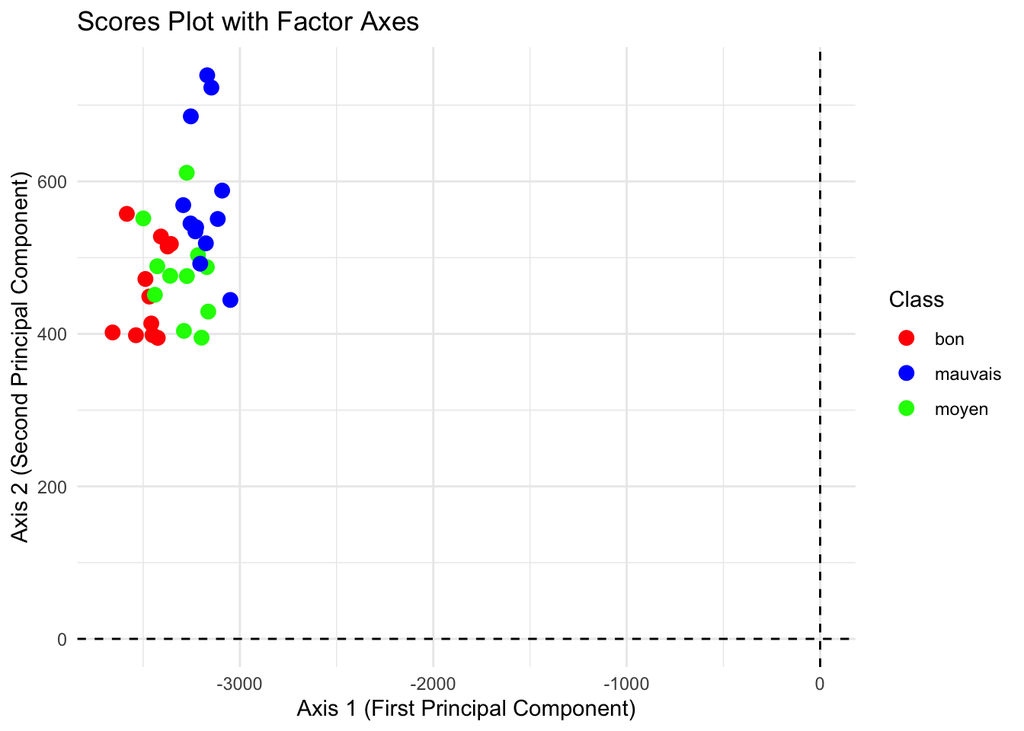

```r
library(ggplot2)
lda_scores <- data.frame(
  Axis1 = results$scores[, 1],  # Scores for the first principal component
  Axis2 = results$scores[, 2],  # Scores for the second principal component
  Class = as.factor(Y)          # Category labels
)

# Use ggplot2 to create a scatter plot and add factor axes
ggplot(lda_scores, aes(x = Axis1, y = Axis2, color = Class)) +
  geom_point(size = 3) +  # Plot the score points
  geom_hline(yintercept = 0, color = "black", linetype = "dashed") +  # Add factor axis 1 (horizontal axis)
  geom_vline(xintercept = 0, color = "black", linetype = "dashed") +  # Add factor axis 2 (vertical axis)
  labs(title = "Scores Plot with Factor Axes",
       x = "Axis 1 (First Principal Component)",
       y = "Axis 2 (Second Principal Component)") +
  theme_minimal() +
  scale_color_manual(values = c("red", "blue", "green"))  # You can adjust the colors
```

The score plot results show the distribution of categories in the reduced dimensional space. There are three categories in total, and although there is some overlap among the categories, most of the data points still show a certain degree of separation in the principal component space, indicating that the model is effective to some extent.

Les Scores sont les suivants:

```r
# Print the score matrix
head(results$scores)
```

```
##           [,1]     [,2]
## [1,] -3216.436 503.2476
## [2,] -3091.826 587.9538
## [3,] -3274.852 611.3355
## [4,] -3168.980 739.2030
## [5,] -3373.477 514.6486
## [6,] -3424.693 394.8144
```

### 3. Classification

#### 3.1 Centres de gravité

- Nous calculons les centres de gravité de chaque groupe dans le plan factoriel. Nous pouvons, par exemple utiliser la fonction *aggregate*.

Combine scores and category labels into a data frame

```r
lda_scores <- data.frame(
  Axis1 = results$scores[, 1],  # Scores for the first principal component
  Axis2 = results$scores[, 2],  # Scores for the second principal component
  Class = as.factor(Y)          # Category labels
)
# Calculate the centroid for each category
centroids <- aggregate(cbind(Axis1, Axis2) ~ Class, data = lda_scores, FUN = mean)

# Print the calculated centroids
print(centroids)
```

```
##     Class     Axis1    Axis2
## 1     bon -3473.612 458.7080
## 2 mauvais -3184.273 577.4675
## 3   moyen -3301.328 479.4350
```

- La représentation des centres de gravité et des individus

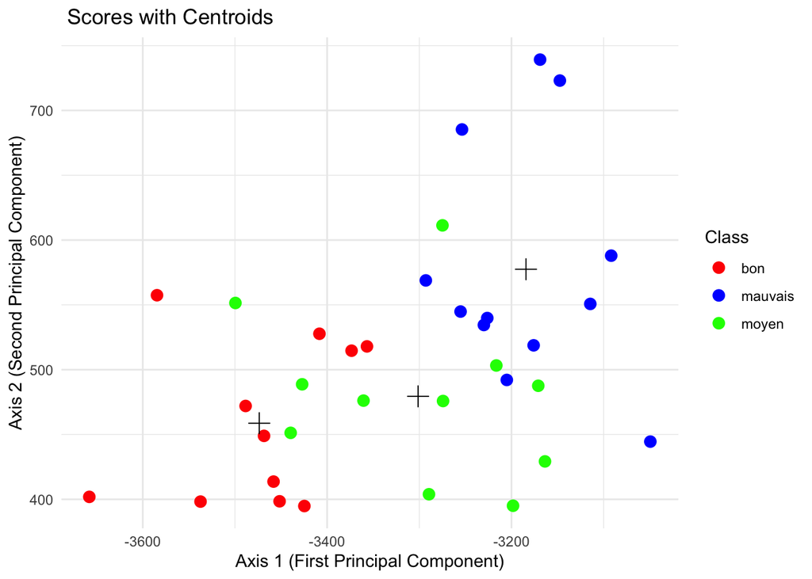

```r
lda_scores <- data.frame(
  Axis1 = results$scores[, 1],  # Scores for the first principal component
  Axis2 = results$scores[, 2],  # Scores for the second principal component
  Class = as.factor(Y)          # Category labels
)
centroids <- aggregate(cbind(Axis1, Axis2) ~ Class, data = lda_scores, FUN = mean)
library(ggplot2)

ggplot(lda_scores, aes(x = Axis1, y = Axis2, color = Class)) +
  geom_point(size = 3) +  # Plot the score points
  geom_point(data = centroids, aes(x = Axis1, y = Axis2),
             color = "black", size = 4, shape = 3) +  # Mark the centroids
  labs(title = " Scores with Centroids",
       x = "Axis 1 (First Principal Component)",
       y = "Axis 2 (Second Principal Component)") +
  theme_minimal() +
  scale_color_manual(values = c("red", "blue", "green"))  # Set colors
```

The data points for the “bon” category are mainly clustered in the lower left, the data points for the “mauvais” category are mainly clustered in the upper right, and the data points for the “moyen” category are located between the two.

#### 3.2 Distances

```r
library(ggplot2)
library(dplyr)
# Calculate Euclidean distances between the centroids of each group
distances <- data.frame()
for (i in 1:(nrow(centroids) - 1)) {
  for (j in (i + 1):nrow(centroids)) {
    dist <- sqrt((centroids$Axis1[i] - centroids$Axis1[j])^2 +
                 (centroids$Axis2[i] - centroids$Axis2[j])^2)
    distances <- rbind(distances, data.frame(Group1 = centroids$Class[i],
                                              Group2 = centroids$Class[j],
                                              Distance = dist))
  }
}
# Print the calculated distances
print(distances)
```

```
##    Group1  Group2 Distance
## 1     bon mauvais 312.7629
## 2     bon   moyen 173.5262
## 3 mauvais   moyen 152.6833
```

[figure not shown]

```r
ggplot() +
  # Plot original data points
  geom_point(data = lda_scores, aes(x = Axis1, y = Axis2, color = as.factor(Class)), size = 3) +
  # Add points for centroids
  geom_point(data = centroids, aes(x = Axis1, y = Axis2, color = Class), size = 5, shape = 17, stroke = 1.5) +
  # Add labels to each centroid
  geom_text(data = centroids, aes(x = Axis1, y = Axis2, label = Class), vjust = -1, hjust = -0.5) +
  # Draw lines connecting centroids
  geom_segment(data = distances,
               aes(x = centroids$Axis1[match(Group1, centroids$Class)],
                   y = centroids$Axis2[match(Group1, centroids$Class)],
                   xend = centroids$Axis1[match(Group2, centroids$Class)],
                   yend = centroids$Axis2[match(Group2, centroids$Class)]),
               color = "black", size = 1, linetype = "dotted") +
  # Chart settings
  labs(title = "Distances between the centroids and the individuals",
       x = "Axis 1 (First principal component)",
       y = "Axis 2 (Second principal component)") +
  theme_minimal() +
  theme(legend.position = "top") +  # Adjust legend position
  scale_color_manual(values = c("red", "blue", "green"))  # Customizable colors
```

From the chart, it’s evident that the centroids of the “bon” and “mauvais” categories are quite far apart, indicating a significant difference between these two categories in the principal component space. The centroid of the “moyen” category lies between the two, suggesting that it shares some similarities with both categories in the feature space.

#### 3.3 Classification

```r
head(lda_scores)
```

```
##       Axis1    Axis2   Class
## 1 -3216.436 503.2476   moyen
## 2 -3091.826 587.9538 mauvais
## 3 -3274.852 611.3355   moyen
## 4 -3168.980 739.2030 mauvais
## 5 -3373.477 514.6486     bon
## 6 -3424.693 394.8144     bon
```

```r
# Assume the Class column contains the predicted category labels, which can be used directly
lda_scores$assigned_class <- lda_scores$Class  # Assign the "Class" column to "assigned_class"
head(lda_scores$assigned_class)
```

```
## [1] moyen   mauvais moyen   mauvais bon     bon
## Levels: bon mauvais moyen
```

```r
#gold_standard <- factor(data$Qualite, levels = c("bon", "moyen", "mauvais"), labels = c(1, 2, 3))
gold_standard <- factor(data$Qualite, levels = c("bon", "moyen", "mauvais"), labels = c(1, 2, 3))

# Ensure the length of `gold_standard` matches the number of rows in `lda_scores`
length(gold_standard)
```

```
## [1] 34
```

```r
nrow(lda_scores)
```

```
## [1] 34
```

```r
# Create a dataframe that includes AFD classification and Gold Standard
comparison_df <- data.frame(
  AFD_Class = lda_scores$assigned_class,  # AFD classification results
  Gold_Standard = gold_standard  # Custom Gold Standard
)

# View the first few rows of the comparison dataframe
head(comparison_df)
```

```
##   AFD_Class Gold_Standard
## 1     moyen             2
## 2   mauvais             3
## 3     moyen             2
## 4   mauvais             3
## 5       bon             1
## 6       bon             1
```

#### 3.4 Qualité

- Nous pouvons maintenant réaliser la matrice des confusions en utilisant la fonction *confusionMatrix* du package *caret*

```r
levels(comparison_df$AFD_Class)
```

```
## [1] "bon"     "mauvais" "moyen"
```

```r
levels(comparison_df$Gold_Standard)
```

```
## [1] "1" "2" "3"
```

```r
table(comparison_df$AFD_Class)
```

```
##
##     bon mauvais   moyen
##      11      12      11
```

```r
table(comparison_df$Gold_Standard)
```

```
##
##  1  2  3
## 11 11 12
```

```r
library(caret)
# Convert Gold_Standard from numeric to character
comparison_df$Gold_Standard <- factor(comparison_df$Gold_Standard,
                                       levels = c(1, 2, 3),
                                       labels = c("bon", "moyen", "mauvais"))
conf_matrix <- confusionMatrix(as.factor(comparison_df$AFD_Class), as.factor(comparison_df$Gold_Standard))
print(conf_matrix)
```

```
## Confusion Matrix and Statistics
##
##           Reference
## Prediction bon moyen mauvais
##    bon      11     0       0
##    moyen     0    11       0
##    mauvais   0     0      12
##
## Overall Statistics
##
##                Accuracy : 1
##                  95% CI : (0.8972, 1)
##     No Information Rate : 0.3529
##     P-Value [Acc > NIR] : 4.187e-16
##
##                   Kappa : 1
##
##  Mcnemar's Test P-Value : NA
##
## Statistics by Class:
##
##                      Class: bon Class: moyen Class: mauvais
## Sensitivity              1.0000       1.0000         1.0000
## Specificity              1.0000       1.0000         1.0000
## Pos Pred Value           1.0000       1.0000         1.0000
## Neg Pred Value           1.0000       1.0000         1.0000
## Prevalence               0.3235       0.3235         0.3529
## Detection Rate           0.3235       0.3235         0.3529
## Detection Prevalence     0.3235       0.3235         0.3529
## Balanced Accuracy        1.0000       1.0000         1.0000
```

#### 3.5 Encapsulation

- On construit une fonction ( que nous appelerons *AFD_Classif*) et qui “encapsule” le code

La fonction doit retourner :

- les centre de gravités
- les distances de chaque individus aux centre des classes (groupes)
- la comparaison entre la classification réalisée par l’AFD et le gold standard
- la matrice de confusion (obtenue à l’aide de la fonction caret)

```r
AFD_Classif <- function(data, nb_axes = 2) {
  # Extract features (X) and category labels (Y)
  X <- as.matrix(data[, 1:4])  # Select the first four columns as features
  Y <- factor(data$Species)    # Use the Species column as the target label (category)

  # Calculate covariance matrices
  SS_tot <- cov(X) * (nrow(X) - 1)
  SS_intra <- cov(X[Y == unique(Y)[1], ]) * sum(Y == unique(Y)[1]) +
    cov(X[Y == unique(Y)[2], ]) * sum(Y == unique(Y)[2]) +
    cov(X[Y == unique(Y)[3], ]) * sum(Y == unique(Y)[3])
  SS_inter <- cov(X[Y == unique(Y)[1], ]) * (nrow(X) - sum(Y == unique(Y)[1])) +
    cov(X[Y == unique(Y)[2], ]) * (nrow(X) - sum(Y == unique(Y)[2])) +
    cov(X[Y == unique(Y)[3], ]) * (nrow(X) - sum(Y == unique(Y)[3]))

  # Apply AFD analysis (ensure the AFD function is defined)
  results <- AFD(X, Y, SS_tot, SS_intra, SS_inter, nb_axes = nb_axes)

  # Create LDA scores dataframe
  lda_scores <- data.frame(
    Axis1 = results$scores[, 1],
    Axis2 = results$scores[, 2],
    Class = as.factor(Y)
  )

  # Calculate centroids for each category
  centroids <- aggregate(cbind(Axis1, Axis2) ~ Class, data = lda_scores, FUN = mean)

  # Calculate Euclidean distance from each sample to its centroid
  distances <- data.frame()
  for (i in 1:nrow(lda_scores)) {
    individual <- lda_scores[i, c("Axis1", "Axis2")]
    centroid <- centroids[centroids$Class == lda_scores$Class[i], c("Axis1", "Axis2")]
    dist <- sqrt((individual$Axis1 - centroid$Axis1)^2 + (individual$Axis2 - centroid$Axis2)^2)
    distances <- rbind(distances, data.frame(Class = lda_scores$Class[i], Distance = dist))
  }

  # Create a comparison dataframe containing AFD classification and Gold Standard
  lda_scores$assigned_class <- lda_scores$Class
  gold_standard <- factor(data$Species, levels = c("setosa", "versicolor", "virginica"))

  comparison_df <- data.frame(
    AFD_Class = lda_scores$assigned_class,
    Gold_Standard = gold_standard
  )

  # Ensure Gold_Standard and AFD_Class have consistent category order
  comparison_df$AFD_Class <- factor(comparison_df$AFD_Class, levels = c("setosa", "versicolor", "virginica"))
  comparison_df$Gold_Standard <- factor(comparison_df$Gold_Standard, levels = c("setosa", "versicolor", "virginica"))

  # Calculate confusion matrix
  library(caret)
  conf_matrix <- confusionMatrix(comparison_df$AFD_Class, comparison_df$Gold_Standard)

  # Return result list
  return(list(
    Centroids = centroids,
    Distances = distances,
    Comparison = comparison_df,
    ConfusionMatrix = conf_matrix
  ))
}
```

### 4. Déploiement

- Pour déployer le code, on utilisera le fichier *iris* fournit par défaut dans R

```r
# Load the iris dataset
data(iris)
result_iris <- AFD_Classif(iris)
```

Les résultats sur le fichier *iris* sont les suivants

- Centres de gravité

```r
print("Centroids:")
```

```
## [1] "Centroids:"
```

```r
print(result_iris$Centroids)
```

```
##        Class     Axis1     Axis2
## 1     setosa 1.9891180 0.4537167
## 2 versicolor 1.1116839 1.0347456
## 3  virginica 0.7319603 1.5630533
```

- Distances

```r
print("Distances:")
```

```
## [1] "Distances:"
```

```r
print(head(result_iris$Distances))
```

```
##    Class   Distance
## 1 setosa 0.09615048
## 2 setosa 0.11343257
## 3 setosa 0.08712251
## 4 setosa 0.25794400
## 5 setosa 0.01766351
## 6 setosa 0.17670282
```

- Classification

```r
print("Comparison:")
```

```
## [1] "Comparison:"
```

```r
print(head(result_iris$Comparison))
```

```
##   AFD_Class Gold_Standard
## 1    setosa        setosa
## 2    setosa        setosa
## 3    setosa        setosa
## 4    setosa        setosa
## 5    setosa        setosa
## 6    setosa        setosa
```

- Confusion

```r
print("Confusion Matrix:")
```

```
## [1] "Confusion Matrix:"
```

```r
print(result_iris$ConfusionMatrix)
```

```
## Confusion Matrix and Statistics
##
##             Reference
## Prediction   setosa versicolor virginica
##   setosa         50          0         0
##   versicolor      0         50         0
##   virginica       0          0        50
##
## Overall Statistics
##
##                Accuracy : 1
##                  95% CI : (0.9757, 1)
##     No Information Rate : 0.3333
##     P-Value [Acc > NIR] : < 2.2e-16
##
##                   Kappa : 1
##
##  Mcnemar's Test P-Value : NA
##
## Statistics by Class:
##
##                      Class: setosa Class: versicolor Class: virginica
## Sensitivity                 1.0000            1.0000           1.0000
## Specificity                 1.0000            1.0000           1.0000
## Pos Pred Value              1.0000            1.0000           1.0000
## Neg Pred Value              1.0000            1.0000           1.0000
## Prevalence                  0.3333            0.3333           0.3333
## Detection Rate              0.3333            0.3333           0.3333
## Detection Prevalence        0.3333            0.3333           0.3333
## Balanced Accuracy           1.0000            1.0000           1.0000
```